```python
from IPython.core.display import display, HTML

display(HTML('''
<div style="background-color: black; padding: 20px;">
    <h1 style="text-align: center; font-size: 3em; color: #FF0000; font-weight: bold;">Análisis de Precios de inmuebles en la Ciudaad de Bogotá, Colombia usando Modelos Supervisados y No Supervisados</h1>
</div>
'''))
```

Análisis de Precios de inmuebles en la Ciudaad de Bogotá, Colombia usando Modelos Supervisados y No Supervisados

```python
from google.colab import drive
drive.mount('/content/drive')
```

# Análisis de Precios de Bogotá Colombia usando Modelos Supervisados y No Supervisados

**Autores:** Richard Javier Oliveros Álvarez

José Antonio Martínez

José Mario Rivera Rivera

Ruberts Stivenson Agudelo

William Bernal

**Fecha:** 23/07/2024

# Índice

```python
from IPython.core.display import display, HTML

display(HTML('''
<div style="background-color: black; padding: 20px;">
<h1 style="text-align: center; font-size: 3em; color: #FF0000; font-weight: bold;">Introducción</h1>
'''))
```

Introducción

## Introducción

El mercado inmobiliario en Bogotá ha mostrado un crecimiento significativo en los últimos años. Sin embargo, la variabilidad en los precios de las propiedades representa un desafío tanto para compradores como para constructores. Este estudio de caso se propone analizar detalladamente los datos disponibles para ofrecer insights valiosos sobre el comportamiento del mercado inmobiliario en Bogotá. Utilizaremos modelos de aprendizaje supervisado y no supervisado para entender mejor los factores que influyen en los precios de las propiedades y proporcionar recomendaciones basadas en datos.

```python
from IPython.core.display import display, HTML

display(HTML('''
<div style="background-color: black; padding: 20px;">
<h1 style="text-align: center; font-size: 3em; color: #FF0000; font-weight: bold;">Objetivos</h1>
'''))
```

Objetivos

## Objetivos

**Objetivo General:** Realizar un análisis de los precios de las propiedades en Bogotá para identificar patrones y factores determinantes que puedan asistir en la toma de decisiones informadas sobre la compra de viviendas.

```python
from IPython.core.display import display, HTML

display(HTML('''
<div style="background-color: black; padding: 20px;">
<h1 style="text-align: center; font-size: 3em; color: #FF0000; font-weight: bold;">Dataset</h1>
'''))
```

Dataset

## Conjunto de Datos

Fuente: https://www.kaggle.com/datasets/pablobravo73/real-estate-bogota

El conjunto de datos de propiedades inmobiliarias en Bogotá incluye información detallada sobre propiedades residenciales y comerciales en diversas áreas de la ciudad. Las columnas relevantes del dataset incluyen:

- **Tipo:** El tipo de propiedad, que puede ser apartamento, casa, oficina, local, lote, bodega, etc.
- **Descripción:** Una breve descripción del inmueble.
- **Habitaciones:** La cantidad de habitaciones en el inmueble.
- **Baños:** La cantidad de baños en el inmueble.
- **Área:** El tamaño del área en metros cuadrados del inmueble.
- **Barrio:** El nombre del barrio donde se encuentra el inmueble.
- **UPZ:** La Unidad de Planeamiento Zonal donde se encuentra el inmueble.
- **Valor:** El valor del inmueble en pesos colombianos.

```python
from IPython.core.display import display, HTML

display(HTML('''
<div style="background-color: black; padding: 20px;">
<h1 style="text-align: center; font-size: 3em; color: #FF0000; font-weight: bold;">Metodología</h1>
'''))
```

Metodología

## Metodología

El análisis se dividirá en dos partes principales: modelos supervisados y modelos no supervisados.

### Modelos Supervisados

Los modelos supervisados utilizan datos etiquetados para predecir resultados futuros. En este estudio, utilizaremos un modelo de Random Forest (RF) para predecir los precios de las propiedades basados en las características disponibles.

### Modelos No Supervisados

Los modelos no supervisados no utilizan datos etiquetados y se utilizan para encontrar patrones ocultos en los datos. Utilizaremos el algoritmo K-Means para agrupar propiedades basadas en características similares.

```python
from IPython.core.display import display, HTML

display(HTML('''
<div style="background-color: black; padding: 20px;">
<h1 style="text-align: center; font-size: 3em; color: #FF0000; font-weight: bold;">Desarrollo del proyecto</h1>
'''))
```

Desarrollo del proyecto

## Desarrollo del Taller

### 1. Cargue del Dataset

```python
from google.colab import drive
drive.mount('/content/drive/')
```

```python
# Importar bibliotecas necesarias
import pandas as pd

# Cargar el conjunto de datos
df = pd.read_csv('/content/inmuebles_bogota.csv')
# Mostrar las primeras filas del dataset
df.head()
```

|  | Tipo | Descripcion | Habitaciones | Baños | Área | Barrio | UPZ | Valor |
| --- | --- | --- | --- | --- | --- | --- | --- | --- |
| 0 | Apartamento | Apartamento en venta en Zona Noroccidental | 3 | 2 | 70 | Zona Noroccidental | CHAPINERO: Pardo Rubio + Chapinero | $ 360.000.000 |
| 1 | Casa | Casa en venta en Castilla | 4 | 3 | 170 | Castilla | KENNEDY: Castilla + Bavaria | $ 670.000.000 |
| 2 | Apartamento | Apartamento en venta en Chico Reservado | 3 | 3 | 144 | Chico Reservado | CHAPINERO: Chicó Lago + El Refugio | $ 1.120.000.000 |
| 3 | Apartamento | Apartamento en venta en Usaquén | 3 | 2 | 154 | Usaquén | Usaquén | $ 890.000.000 |
| 4 | Apartamento | Apartamento en venta en Bella Suiza | 2 | 3 | 128 | Bella Suiza | USAQUÉN: Country Club + Santa Bárbara | $ 970.000.000 |

## Exploración Inicial de los Datos

Vamos a examinar las primeras filas del dataset y algunas estadísticas básicas para comprender mejor su estructura y contenido.

```python
# Mostrar información general del dataset
df.info()

# Describir las estadísticas de las variables numéricas
df.describe()
```

```
<class 'pandas.core.frame.DataFrame'>
RangeIndex: 9520 entries, 0 to 9519
Data columns (total 8 columns):
 #   Column        Non-Null Count  Dtype
---  ------        --------------  -----
 0   Tipo          9520 non-null   object
 1   Descripcion   9520 non-null   object
 2   Habitaciones  9520 non-null   int64
 3   Baños         9520 non-null   int64
 4   Área          9520 non-null   int64
 5   Barrio        9520 non-null   object
 6   UPZ           9478 non-null   object
 7   Valor         9520 non-null   object
dtypes: int64(3), object(5)
memory usage: 595.1+ KB
```

|  | Habitaciones | Baños | Área |
| --- | --- | --- | --- |
| count | 9520.000000 | 9520.000000 | 9520.000000 |
| mean | 3.072479 | 2.447899 | 146.664706 |
| std | 2.049856 | 1.255314 | 1731.379622 |
| min | 1.000000 | 0.000000 | 2.000000 |
| 25% | 2.000000 | 2.000000 | 57.000000 |
| 50% | 3.000000 | 2.000000 | 80.000000 |
| 75% | 3.000000 | 3.000000 | 135.000000 |
| max | 110.000000 | 9.000000 | 166243.000000 |

## Análisis Descriptivo

Analizaremos las variables categóricas y numéricas para entender su distribución y posibles valores atípicos.

```python
# Análisis de las variables categóricas
categorical_columns = df.select_dtypes(include=['object']).columns
df[categorical_columns].describe()

# Análisis de las variables numéricas
numerical_columns = df.select_dtypes(include=['number']).columns
df[numerical_columns].describe()
```

|  | Habitaciones | Baños | Área |
| --- | --- | --- | --- |
| count | 9520.000000 | 9520.000000 | 9520.000000 |
| mean | 3.072479 | 2.447899 | 146.664706 |
| std | 2.049856 | 1.255314 | 1731.379622 |
| min | 1.000000 | 0.000000 | 2.000000 |
| 25% | 2.000000 | 2.000000 | 57.000000 |
| 50% | 3.000000 | 2.000000 | 80.000000 |
| 75% | 3.000000 | 3.000000 | 135.000000 |
| max | 110.000000 | 9.000000 | 166243.000000 |

## Visualización de los Datos

Usaremos gráficos para visualizar la distribución de las variables más relevantes.

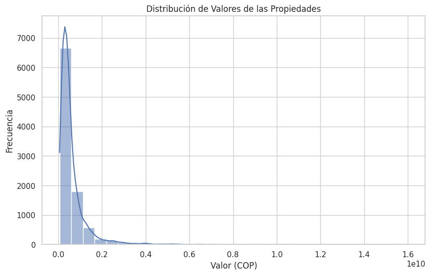

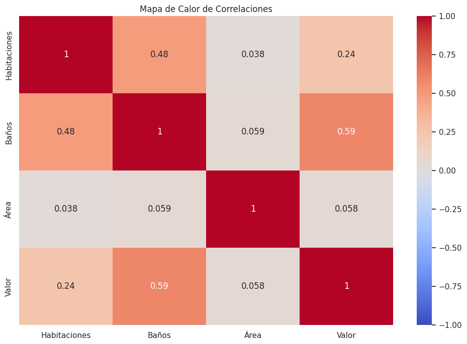

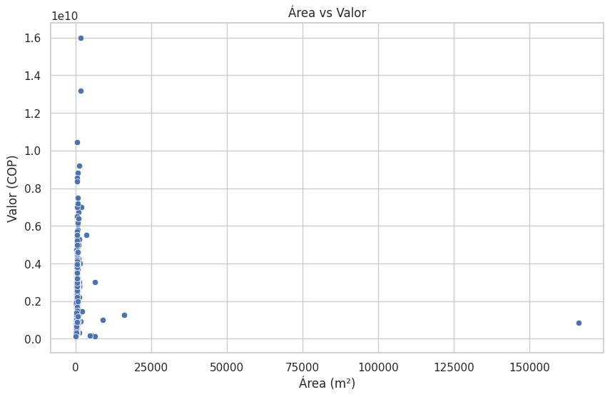

```python
# Importar librerías de visualización
import matplotlib.pyplot as plt
import seaborn as sns
import pandas as pd

# Limpiar y convertir la columna 'Valor' a un formato numérico adecuado
df['Valor'] = df['Valor'].str.replace('[\$,]', '', regex=True).str.replace(' ', '').str.replace('.', '').astype(float)

# Configurar estilo de los gráficos
sns.set(style="whitegrid")

# Histograma de los valores de las propiedades
plt.figure(figsize=(10, 6))
sns.histplot(df['Valor'], kde=True, bins=30)
plt.title('Distribución de Valores de las Propiedades')
plt.xlabel('Valor (COP)')
plt.ylabel('Frecuencia')
plt.show()

# Seleccionar solo las columnas numéricas para el análisis de correlación
numerical_df = df[['Habitaciones', 'Baños', 'Área', 'Valor']]

# Mapa de calor de correlaciones entre variables numéricas
plt.figure(figsize=(12, 8))
correlation_matrix = numerical_df.corr()
sns.heatmap(correlation_matrix, annot=True, cmap='coolwarm', vmin=-1, vmax=1)
plt.title('Mapa de Calor de Correlaciones')
plt.show()

# Gráfico de dispersión de área vs valor
plt.figure(figsize=(10, 6))
sns.scatterplot(x='Área', y='Valor', data=numerical_df)
plt.title('Área vs Valor')
plt.xlabel('Área (m²)')
plt.ylabel('Valor (COP)')
plt.show()
```

## Limpieza de los Datos

Para realizar una predicción precisa del valor de los inmuebles, seleccionamos las siguientes variables y eliminamos aquellas que no aportan información relevante al modelo, como la descripción y la UPZ:

- **Tipo:** El tipo de propiedad, que puede ser apartamento, casa, oficina, local, lote, bodega, etc.
- **Habitaciones:** La cantidad de habitaciones en el inmueble.
- **Baños:** La cantidad de baños en el inmueble.
- **Área:** El tamaño del área en metros cuadrados del inmueble.
- **Barrio:** El nombre del barrio donde se encuentra el inmueble.
- **Valor:** El valor del inmueble en pesos colombianos.

### Justificación

1. **Tipo:** El tipo de propiedad es un factor determinante del valor, ya que diferentes tipos de propiedades (apartamentos, casas, oficinas, etc.) tienen distintos valores en el mercado.
2. **Habitaciones y Baños:** Estas características físicas del inmueble influyen directamente en su precio, ya que una mayor cantidad de habitaciones y baños generalmente aumenta el valor.
3. **Área:** El tamaño de la propiedad es crucial para la determinación del precio. Propiedades con mayor área suelen tener un mayor valor.
4. **Barrio:** La ubicación es uno de los factores más importantes en la valoración de propiedades. Diferentes barrios tienen distintas valoraciones de mercado.
5. **Valor:** Esta es la variable objetivo que deseamos predecir.

# Eliminar Columnas Innecesarias

```python
# Seleccionar solo las columnas relevantes
columns_to_keep = ['Tipo', 'Habitaciones', 'Baños', 'Área', 'Barrio', 'Valor']
df_cleaned = df[columns_to_keep]

# Mostrar información general del nuevo dataframe
print(df_cleaned.info())
print(df_cleaned.head())
```

```
<class 'pandas.core.frame.DataFrame'>
RangeIndex: 9520 entries, 0 to 9519
Data columns (total 6 columns):
 #   Column        Non-Null Count  Dtype
---  ------        --------------  -----
 0   Tipo          9520 non-null   object
 1   Habitaciones  9520 non-null   int64
 2   Baños         9520 non-null   int64
 3   Área          9520 non-null   int64
 4   Barrio        9520 non-null   object
 5   Valor         9520 non-null   float64
dtypes: float64(1), int64(3), object(2)
memory usage: 446.4+ KB
None
          Tipo  Habitaciones  Baños  Área              Barrio         Valor
0  Apartamento             3      2    70  Zona Noroccidental  3.600000e+08
1         Casa             4      3   170            Castilla  6.700000e+08
2  Apartamento             3      3   144     Chico Reservado  1.120000e+09
3  Apartamento             3      2   154             Usaquén  8.900000e+08
4  Apartamento             2      3   128         Bella Suiza  9.700000e+08
```

## Tratamiento de Valores Nulos

Revisaremos y trataremos los valores nulos en nuestro dataset. Dependiendo de la cantidad de valores faltantes, podremos eliminar filas o imputar valores.

```python
# Verificar la cantidad de valores nulos por columna después de la limpieza inicial
print(df_cleaned.isnull().sum())

# Eliminar filas con valores nulos en la columna 'Valor' ya que es nuestra variable objetivo
df_cleaned = df_cleaned.dropna(subset=['Valor'])

# Rellenar valores nulos en las columnas numéricas con la mediana de cada columna
for col in ['Habitaciones', 'Baños', 'Área']:
    if col in df_cleaned.columns:
        df_cleaned[col].fillna(df_cleaned[col].median(), inplace=True)

# Verificar si hay valores nulos en las columnas categóricas
categorical_columns = ['Tipo', 'Barrio']
print(df_cleaned[categorical_columns].isnull().sum())

# Mostrar las primeras filas del dataframe limpio
print(df_cleaned.head())
```

```
Tipo            0
Habitaciones    0
Baños           0
Área            0
Barrio          0
Valor           0
dtype: int64
Tipo      0
Barrio    0
dtype: int64
          Tipo  Habitaciones  Baños  Área              Barrio         Valor
0  Apartamento             3      2    70  Zona Noroccidental  3.600000e+08
1         Casa             4      3   170            Castilla  6.700000e+08
2  Apartamento             3      3   144     Chico Reservado  1.120000e+09
3  Apartamento             3      2   154             Usaquén  8.900000e+08
4  Apartamento             2      3   128         Bella Suiza  9.700000e+08
```

# Codificación de Variables Categóricas

```python
from sklearn.preprocessing import LabelEncoder

# Inicializar el codificador de etiquetas
label_encoder = LabelEncoder()

# Diccionario para almacenar los codificadores y sus respectivas categorías
label_encoders = {}

# Codificar cada columna categórica y almacenar el codificador
categorical_columns = ['Tipo', 'Barrio']
for col in categorical_columns:
    if col in df_cleaned.columns:
        df_cleaned[col] = label_encoder.fit_transform(df_cleaned[col])
        label_encoders[col] = label_encoder.classes_

# Verificar el resultado de la codificación
print(df_cleaned.head())

# Imprimir los valores codificados para cada columna categórica de manera clara
for col in categorical_columns:
    if col in label_encoders:
        print(f"Categorías para la columna '{col}':")
        for index, category in enumerate(label_encoders[col]):
            print(f"{category} --> {index}")
        print("\n" + "-"*50 + "\n")

# Guardar el dataset limpio para su uso posterior
df_cleaned.to_csv('/content/drive/MyDrive/inmuebles_bogota_cleaned.csv', index=False)

# Mostrar las primeras filas del dataset limpio
print(df_cleaned.head())
```

```
   Tipo  Habitaciones  Baños  Área  Barrio         Valor
0     0             3      2    70     148  3.600000e+08
1     2             4      3   170      21  6.700000e+08
2     0             3      3   144      30  1.120000e+09
3     0             3      2   154     138  8.900000e+08
4     0             2      3   128       6  9.700000e+08
Categorías para la columna 'Tipo':
Apartamento --> 0
Bodega --> 1
Casa --> 2
Edificio --> 3
Finca --> 4
Local --> 5
Lote --> 6
Oficina/Consultorio --> 7

--------------------------------------------------

Categorías para la columna 'Barrio':
Alameda --> 0
Alhambra --> 1
Andes Norte --> 2
Antonio Nariño --> 3
Barrancas --> 4
Barrios Unidos --> 5
Bella Suiza --> 6
Bellavista Occidental --> 7
Bochica --> 8
Bogotá D.C --> 9
Bosa --> 10
Bosa Piamonte --> 11
Bosa Porvenir --> 12
Bosque De Pinos --> 13
Bosque Popular --> 14
Boyaca  --> 15
Buenos Aires --> 16
Candelaria La Nueva --> 17
Cantagallo --> 18
Capellania --> 19
Casablanca --> 20
```

[output cut: 122 more lines]

```
Villa Alsacia --> 143
Villa Maria --> 144
Villas De Granada --> 145
Villemar --> 146
Zona Franca --> 147
Zona Noroccidental --> 148

--------------------------------------------------

   Tipo  Habitaciones  Baños  Área  Barrio         Valor
0     0             3      2    70     148  3.600000e+08
1     2             4      3   170      21  6.700000e+08
2     0             3      3   144      30  1.120000e+09
3     0             3      2   154     138  8.900000e+08
4     0             2      3   128       6  9.700000e+08
```

## Argumentación de la Selección de Variables

Las variables seleccionadas se eligieron por su relevancia directa en la determinación del precio de las propiedades:

- **Tipo (Tipo)**: El tipo de propiedad es crucial ya que diferentes tipos de propiedades (apartamentos, casas, oficinas, etc.) tienen distintos rangos de precios.
- **Habitaciones (Habitaciones)**: El número de habitaciones influye en el valor de una propiedad, ya que más habitaciones generalmente aumentan el valor.
- **Baños (Baños)**: La cantidad de baños también afecta el valor, ya que una mayor cantidad de baños es un factor positivo en la valoración.
- **Área (Área)**: El tamaño del área en metros cuadrados es fundamental para determinar el precio, ya que propiedades más grandes suelen tener mayor valor.
- **Barrio (Barrio)**: La ubicación es uno de los factores más importantes en la valoración de propiedades. Diferentes barrios tienen distintas valoraciones de mercado.
- **Valor (Valor)**: Esta es nuestra variable objetivo, que deseamos predecir.

La limpieza y codificación de estas variables nos permiten preparar el dataset para la construcción de modelos de Machine Learning eficaces.

# Descripción del Dataset y Codificación de Variables Categóricas

## Descripción del Nuevo Dataset

Nuestro dataset limpio y transformado está compuesto por las siguientes variables:

- **Tipo (Tipo):** Codificación del tipo de propiedad (ej. apartamento, casa, etc.).
- **Habitaciones (Habitaciones):** Número de habitaciones en la propiedad.
- **Baños (Baños):** Número de baños en la propiedad.
- **Área (Área):** Superficie total de la propiedad en metros cuadrados.
- **Barrio (Barrio):** Codificación de los diferentes barrios donde se encuentran las propiedades.
- **Valor (Valor):** Precio de la propiedad (variable objetivo).

## Codificación de Variables Categóricas

La codificación de las variables categóricas se encuentra en el archivo: `categoricas_codificadas_bogota.txt`. A continuación, se muestra un resumen de algunas categorías para cada variable:

| Columna | Ejemplos de Categorías |
| --- | --- |
| Tipo | 0: Apartamento 1: Bodega 2: Casa 3: Edificio 4: Finca |
| Barrio | 0: Alameda 1: Alhambra 2: Andes Norte 3: Antonio Nariño 4: Barrancas |

La limpieza y codificación de estas variables nos permiten preparar el dataset para la construcción de modelos de Machine Learning eficaces.

## División de los Datos de Entrenamiento y de Test

Dividiremos nuestro dataset en conjuntos de entrenamiento y de test para poder entrenar y evaluar el modelo de predicción de precios de propiedades. Utilizaremos un 80% de los datos para el entrenamiento y un 20% para el test.

```python
from sklearn.model_selection import train_test_split

# Definir las características (X) y la variable objetivo (y)
X = df_cleaned.drop('Valor', axis=1)
y = df_cleaned['Valor']

# Dividir los datos en conjuntos de entrenamiento y de test (80% entrenamiento, 20% test)
X_train, X_test, y_train, y_test = train_test_split(X, y, test_size=0.2, random_state=42)

# Mostrar el tamaño de los conjuntos
print(f'Tamaño del conjunto de entrenamiento: {X_train.shape[0]} muestras')
print(f'Tamaño del conjunto de test: {X_test.shape[0]} muestras')
```

```
Tamaño del conjunto de entrenamiento: 7616 muestras
Tamaño del conjunto de test: 1904 muestras
```

## Implementación del Modelo Random Forest

Utilizaremos el algoritmo Random Forest para predecir el precio de las propiedades. Entrenaremos el modelo con el conjunto de entrenamiento y evaluaremos su rendimiento utilizando métricas como el error cuadrático medio, el error absoluto medio y el coeficiente de determinación (R²).

```python
from sklearn.ensemble import RandomForestRegressor
from sklearn.model_selection import train_test_split
from sklearn.metrics import mean_squared_error, mean_absolute_error, r2_score

# Inicializar el modelo Random Forest
rf = RandomForestRegressor(n_estimators=100, random_state=42)

# Entrenar el modelo con el conjunto de entrenamiento
rf.fit(X_train, y_train)
```

```
RandomForestRegressor(random_state=42)
```

# Prueba del Modelo Supervisado

```python
from sklearn.metrics import mean_squared_error, mean_absolute_error, r2_score

# Realizar predicciones
y_pred = rf.predict(X_test)

# Evaluar el modelo
mse = mean_squared_error(y_test, y_pred)
mae = mean_absolute_error(y_test, y_pred)
r2 = r2_score(y_test, y_pred)

print(f'Mean Squared Error: {mse}')
print(f'Mean Absolute Error: {mae}')
print(f'R^2 Score: {r2}')
```

```
Mean Squared Error: 1.703127609345893e+17
Mean Absolute Error: 130375952.02775586
R^2 Score: 0.703949544943546
```

### Interpretación de los Resultados del Modelo

Al evaluar los resultados obtenidos del modelo Random Forest, podemos hacer las siguientes observaciones:

1. **Error Cuadrático Medio (MSE):**
   - **Valor:** (1.703127609345893 \times 10^{17})
   - **Interpretación:** El MSE es extremadamente alto, lo que indica que hay una gran diferencia entre los valores predichos y los valores reales. Esto sugiere que el modelo no está prediciendo con precisión los precios de las propiedades.
2. **Error Absoluto Medio (MAE):**
   - **Valor:** (130,375,952.03)
   - **Interpretación:** El MAE también es muy alto, lo que significa que, en promedio, las predicciones del modelo están desviadas por unos 130 millones de la moneda utilizada. Esta gran desviación refuerza la idea de que el modelo no es preciso.
3. **Coeficiente de Determinación (R²):**
   - **Valor:** (0.7039)
   - **Interpretación:** El R² de aproximadamente 0.704 indica que el 70.39% de la variación en los precios de las propiedades es explicada por el modelo. Aunque este valor sugiere que el modelo captura una cantidad significativa de la variabilidad en los datos, la alta magnitud de los errores absolutos y cuadrados medios sugiere que las predicciones individuales pueden ser inexactas.

```python
from IPython.core.display import display, HTML

display(HTML('''
<div style="background-color: black; padding: 20px;">
<h1 style="text-align: center; font-size: 3em; color: #FF0000; font-weight: bold;">Evaluando otros modelos</h1>
'''))
```

Evaluando otros modelos

# Evaluando otros modelos

```python
from IPython.core.display import display, HTML

display(HTML('''
<div style="background-color: black; padding: 20px;">
<h1 style="text-align: center; font-size: 3em; color: #FF0000; font-weight: bold;">XGBoost</h1>
'''))
```

XGBoost

# XGBoost

```python
import xgboost as xgb
from sklearn.model_selection import train_test_split
from sklearn.metrics import mean_squared_error, mean_absolute_error, r2_score

# Dividir los datos en conjunto de entrenamiento y prueba
X_train, X_test, y_train, y_test = train_test_split(X, y, test_size=0.2, random_state=42)

# Inicializar el modelo XGBoost
xg_reg = xgb.XGBRegressor(objective ='reg:squarederror', colsample_bytree = 0.3, learning_rate = 0.1,
                max_depth = 5, alpha = 10, n_estimators = 100, random_state=42)

# Entrenar el modelo con el conjunto de entrenamiento
xg_reg.fit(X_train, y_train)

# Realizar predicciones
y_pred = xg_reg.predict(X_test)

# Evaluar el modelo
mse = mean_squared_error(y_test, y_pred)
mae = mean_absolute_error(y_test, y_pred)
r2 = r2_score(y_test, y_pred)

print(f'Mean Squared Error: {mse}')
print(f'Mean Absolute Error: {mae}')
print(f'R^2 Score: {r2}')
```

```
Mean Squared Error: 2.648187448448169e+17
Mean Absolute Error: 212964056.05357143
R^2 Score: 0.5396721332648855
```

```python
from IPython.core.display import display, HTML

display(HTML('''
<div style="background-color: black; padding: 20px;">
<h1 style="text-align: center; font-size: 3em; color: #FF0000; font-weight: bold;">LightGBM</h1>
'''))
```

LightGBM

# LightGBM

```python
import lightgbm as lgb
from sklearn.model_selection import train_test_split
from sklearn.metrics import mean_squared_error, mean_absolute_error, r2_score

# Dividir los datos en conjunto de entrenamiento y prueba
X_train, X_test, y_train, y_test = train_test_split(X, y, test_size=0.2, random_state=42)

# Inicializar el modelo LightGBM
lgb_reg = lgb.LGBMRegressor(objective='regression', num_leaves=31, learning_rate=0.05, n_estimators=100, random_state=42)

# Entrenar el modelo con el conjunto de entrenamiento
lgb_reg.fit(X_train, y_train)

# Realizar predicciones
y_pred = lgb_reg.predict(X_test)

# Evaluar el modelo
mse = mean_squared_error(y_test, y_pred)
mae = mean_absolute_error(y_test, y_pred)
r2 = r2_score(y_test, y_pred)

print(f'Mean Squared Error: {mse}')
print(f'Mean Absolute Error: {mae}')
print(f'R^2 Score: {r2}')
```

```
[LightGBM] [Info] Auto-choosing row-wise multi-threading, the overhead of testing was 0.001200 seconds.
You can set `force_row_wise=true` to remove the overhead.
And if memory is not enough, you can set `force_col_wise=true`.
[LightGBM] [Info] Total Bins 413
[LightGBM] [Info] Number of data points in the train set: 7616, number of used features: 5
[LightGBM] [Info] Start training from score 600530493.878151
Mean Squared Error: 1.8801504220551046e+17
Mean Absolute Error: 154696905.3635254
R^2 Score: 0.6731781077533149
```

```python
from IPython.core.display import display, HTML

display(HTML('''
<div style="background-color: black; padding: 20px;">
<h1 style="text-align: center; font-size: 3em; color: #FF0000; font-weight: bold;">SVR</h1>
'''))
```

SVR

# SVR

```python
from sklearn.svm import SVR
from sklearn.model_selection import train_test_split
from sklearn.metrics import mean_squared_error, mean_absolute_error, r2_score
from sklearn.preprocessing import StandardScaler

# Escalar las características
scaler = StandardScaler()
X_scaled = scaler.fit_transform(X)

# Dividir los datos en conjunto de entrenamiento y prueba
X_train, X_test, y_train, y_test = train_test_split(X_scaled, y, test_size=0.2, random_state=42)

# Inicializar el modelo SVR
svr = SVR(kernel='rbf', C=100, gamma=0.1, epsilon=0.1)

# Entrenar el modelo con el conjunto de entrenamiento
svr.fit(X_train, y_train)

# Realizar predicciones
y_pred = svr.predict(X_test)

# Evaluar el modelo
mse = mean_squared_error(y_test, y_pred)
mae = mean_absolute_error(y_test, y_pred)
r2 = r2_score(y_test, y_pred)

print(f'Mean Squared Error: {mse}')
print(f'Mean Absolute Error: {mae}')
print(f'R^2 Score: {r2}')
```

```
Mean Squared Error: 6.153223986682067e+17
Mean Absolute Error: 356905746.8412542
R^2 Score: -0.06959968902221414
```

```python
from IPython.core.display import display, HTML

display(HTML('''
<div style="background-color: black; padding: 20px;">
<h1 style="text-align: center; font-size: 3em; color: #FF0000; font-weight: bold;">Regresión Lineal</h1>
'''))
```

Regresión Lineal

# Regresión Lineal

```python
from sklearn.linear_model import LinearRegression
from sklearn.model_selection import train_test_split
from sklearn.metrics import mean_squared_error, mean_absolute_error, r2_score

# Dividir los datos en conjunto de entrenamiento y prueba
X_train, X_test, y_train, y_test = train_test_split(X, y, test_size=0.2, random_state=42)

# Inicializar el modelo de regresión lineal
lr = LinearRegression()

# Entrenar el modelo con el conjunto de entrenamiento
lr.fit(X_train, y_train)

# Realizar predicciones
y_pred = lr.predict(X_test)

# Evaluar el modelo
mse = mean_squared_error(y_test, y_pred)
mae = mean_absolute_error(y_test, y_pred)
r2 = r2_score(y_test, y_pred)

print(f'Mean Squared Error: {mse}')
print(f'Mean Absolute Error: {mae}')
print(f'R^2 Score: {r2}')
```

```
Mean Squared Error: 4.270050603968436e+17
Mean Absolute Error: 285090233.7531025
R^2 Score: 0.25774767699030254
```

```python
from IPython.core.display import display, HTML

display(HTML('''
<div style="background-color: black; padding: 20px;">
<h1 style="text-align: center; font-size: 3em; color: #FF0000; font-weight: bold;">Regularización L2</h1>
'''))
```

Regularización L2

# Ridge Regression (Regularización L2)

```python
from sklearn.linear_model import Ridge
from sklearn.model_selection import train_test_split
from sklearn.metrics import mean_squared_error, mean_absolute_error, r2_score

# Dividir los datos en conjunto de entrenamiento y prueba
X_train, X_test, y_train, y_test = train_test_split(X, y, test_size=0.2, random_state=42)

# Inicializar el modelo de regresión Ridge
ridge = Ridge(alpha=1.0)

# Entrenar el modelo con el conjunto de entrenamiento
ridge.fit(X_train, y_train)

# Realizar predicciones
y_pred = ridge.predict(X_test)

# Evaluar el modelo
mse = mean_squared_error(y_test, y_pred)
mae = mean_absolute_error(y_test, y_pred)
r2 = r2_score(y_test, y_pred)

print(f'Mean Squared Error: {mse}')
print(f'Mean Absolute Error: {mae}')
print(f'R^2 Score: {r2}')
```

```
Mean Squared Error: 4.270010439141231e+17
Mean Absolute Error: 285078807.65768206
R^2 Score: 0.2577546587427596
```

```python
from IPython.core.display import display, HTML

display(HTML('''
<div style="background-color: black; padding: 20px;">
<h1 style="text-align: center; font-size: 3em; color: #FF0000; font-weight: bold;">Comparación de Modelos</h1>
'''))
```

Comparación de Modelos

### Comparación de Modelos

[output not shown]

### Conclusión

**El mejor modelo** basado en los resultados obtenidos es el **Random Forest**. Este modelo tiene el mejor R² Score (0.7039), lo que indica que explica mejor la variabilidad de los precios de las propiedades. Además, tiene el MAE más bajo (130,375,952.03), lo que sugiere que sus predicciones están más cerca de los valores reales en promedio. Por lo tanto, el modelo Random Forest es el más adecuado para predecir los precios de las propiedades en este caso.

```python
from IPython.core.display import display, HTML

display(HTML('''
<div style="background-color: black; padding: 20px;">
<h1 style="text-align: center; font-size: 3em; color: #FF0000; font-weight: bold;">MEJORANDO LOS RESULTADOS</h1>
'''))
```

MEJORANDO LOS RESULTADOS

# Analizaremos de mejor forma los datos para ver si existe ruido u otliers

```python
# Importar bibliotecas necesarias
import pandas as pd

# Cargar el conjunto de datos
df = pd.read_csv('/content/inmuebles_bogota.csv')

# Asegurarse de que los valores en la columna 'Valor' sean numéricos
df['Valor'] = df['Valor'].replace('[\$,]', '', regex=True).str.replace(' ', '').str.replace('.', '').astype(float)
```

Análisis Descriptivo y Visualización de Datos Realiza análisis descriptivos y visualización de datos en el dataset original.

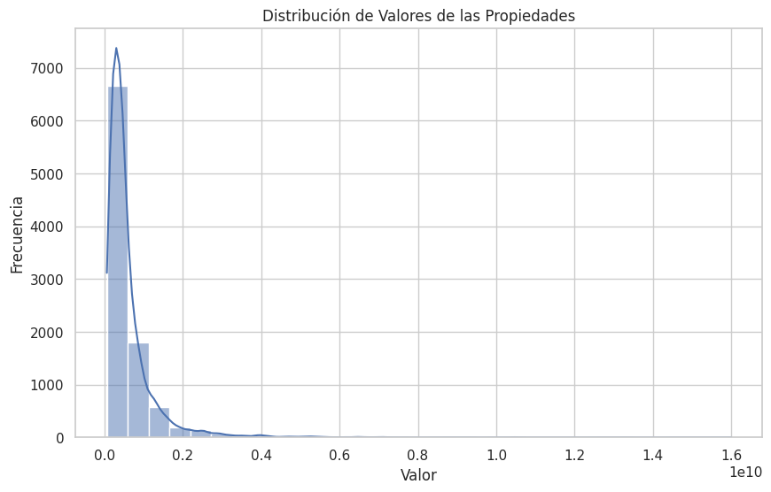

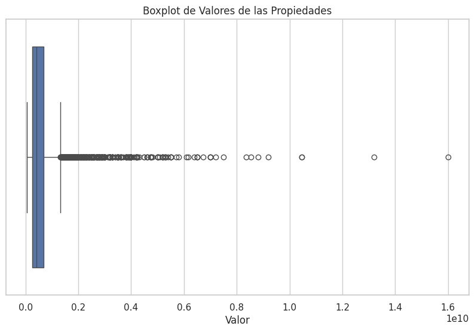

```
count    9.520000e+03
mean     6.020624e+08
std      7.046021e+08
min      6.000000e+07
25%      2.500000e+08
50%      4.091825e+08
75%      6.800000e+08
max      1.600000e+10
Name: Valor, dtype: float64
```

```python
import matplotlib.pyplot as plt
import seaborn as sns

# Histograma de los valores de las propiedades
plt.figure(figsize=(10, 6))
sns.histplot(df['Valor'], bins=30, kde=True)
plt.title('Distribución de Valores de las Propiedades')
plt.xlabel('Valor')
plt.ylabel('Frecuencia')
plt.show()

# Boxplot para la variable objetivo 'Valor'
plt.figure(figsize=(10, 6))
sns.boxplot(x=df['Valor'])
plt.title('Boxplot de Valores de las Propiedades')
plt.xlabel('Valor')
plt.show()

# Estadísticas descriptivas
print(df['Valor'].describe())
```

### Análisis de las Gráficas

#### 1. Distribución de Valores de las Propiedades

- **Interpretación:**
  - La mayoría de los valores de las propiedades están concentrados en el rango más bajo.
  - La distribución muestra una larga cola hacia la derecha, indicando la presencia de propiedades con precios extremadamente altos (outliers).

#### 2. Boxplot de Valores de las Propiedades

- **Interpretación:**
  - El boxplot confirma la presencia de numerosos outliers en los datos.
  - La mayoría de los datos se encuentran en un rango estrecho, pero hay valores extremos muy altos que se alejan del rango intercuartílico (IQR).

### Conclusiones

Utiliza el método del rango intercuartílico (IQR) para identificar outliers.

```python
# Calcular IQR
Q1 = df['Valor'].quantile(0.25)
Q3 = df['Valor'].quantile(0.75)
IQR = Q3 - Q1

# Definir límites
lower_bound = Q1 - 1.5 * IQR
upper_bound = Q3 + 1.5 * IQR

# Filtrar outliers
outliers = df[(df['Valor'] < lower_bound) | (df['Valor'] > upper_bound)]

# Mostrar outliers
print(outliers)
```

```
             Tipo                              Descripcion  Habitaciones  \
7     Apartamento      Apartamento en venta en Bella Suiza             3
15           Casa      Casa en venta en Zona Noroccidental             3
19           Casa      Casa en venta en Zona Noroccidental             3
22           Casa      Casa en venta en Zona Noroccidental             3
23           Casa      Casa en venta en Zona Noroccidental             5
...           ...                                      ...           ...
9466        Local          Local en venta en Puente Aranda            15
9480        Local           Local en venta en Las Delicias             9
9495  Apartamento        Apartamento en venta en Chapinero             4
9506  Apartamento  Apartamento en venta en Chico Reservado             3
9511  Apartamento  Apartamento en venta en Nueva Autopista             4

      Baños  Área              Barrio  \
7         4   212         Bella Suiza
```

[output cut: 25 more lines]

### Análisis de Outliers Identificados mediante IQR

#### Resultados de Outliers Identificados

A continuación se presentan algunos de los outliers identificados mediante el método del Rango Intercuartílico (IQR):

| Tipo | Descripción | Habitaciones | Baños | Área | Barrio | UPZ | Valor |
| --- | --- | --- | --- | --- | --- | --- | --- |
| Apartamento | Apartamento en venta en Bella Suiza | 3 | 4 | 212 | Bella Suiza | USAQUÉN: Country Club + Santa Bárbara | 2.350000e+09 |
| Casa | Casa en venta en Zona Noroccidental | 3 | 4 | 300 | Zona Noroccidental | CHAPINERO: Pardo Rubio + Chapinero | 2.519000e+09 |
| Casa | Casa en venta en Zona Noroccidental | 3 | 6 | 380 | Zona Noroccidental | CHAPINERO: Pardo Rubio + Chapinero | 1.600000e+09 |
| Casa | Casa en venta en Zona Noroccidental | 3 | 5 | 365 | Zona Noroccidental | CHAPINERO: Pardo Rubio + Chapinero | 2.799000e+09 |
| Casa | Casa en venta en Zona Noroccidental | 5 | 5 | 450 | Zona Noroccidental | CHAPINERO: Pardo Rubio + Chapinero | 1.450000e+09 |
| Local | Local en venta en Puente Aranda | 15 | 9 | 114 | Puente Aranda | PUENTE ARANDA: Zona Industrial + Puente Aranda | 1.400000e+09 |
| Local | Local en venta en Las Delicias | 9 | 7 | 495 | Las Delicias | Usaquén | 1.500000e+09 |
| Apartamento | Apartamento en venta en Chapinero | 4 | 4 | 366 | Chapinero | CHAPINERO: Pardo Rubio + Chapinero | 3.950000e+09 |
| Apartamento | Apartamento en venta en Chico Reservado | 3 | 4 | 390 | Chico Reservado | CHAPINERO: Chicó Lago + El Refugio | 3.200000e+09 |
| Apartamento | Apartamento en venta en Nueva Autopista | 4 | 5 | 250 | Nueva Autopista | Los Cedros | 1.375000e+09 |

... y otros 758 registros de outliers.

### Interpretación

1. **Características de los Outliers:**
   - Los outliers identificados tienen precios extremadamente altos en comparación con la mayoría de los datos.
   - Estos registros presentan variabilidad en el tipo de propiedad, ubicación y características físicas (número de habitaciones, baños y área).
2. **Impacto en el Modelo:**
   - La presencia de estos outliers puede distorsionar los resultados del modelo, aumentando el error y reduciendo la precisión de las predicciones.
   - Los modelos de machine learning pueden ser sensibles a estos valores extremos, lo que puede llevar a un rendimiento subóptimo.

Eliminacion de outliers

```python
# Eliminar outliers
df_no_outliers = df[(df['Valor'] >= lower_bound) & (df['Valor'] <= upper_bound)]

# Verificar el nuevo dataset sin outliers
print(df_no_outliers.describe())
print(df_no_outliers.head())
```

```
       Habitaciones        Baños           Área         Valor
count   8752.000000  8752.000000    8752.000000  8.752000e+03
mean       2.952468     2.267025     127.085352  4.479720e+08
std        1.918349     1.057752    1801.871210  2.773851e+08
min        1.000000     0.000000       2.000000  6.000000e+07
25%        2.000000     2.000000      55.000000  2.380000e+08
50%        3.000000     2.000000      76.000000  3.864950e+08
75%        3.000000     3.000000     114.000000  5.750000e+08
max      110.000000     9.000000  166243.000000  1.320000e+09
          Tipo                                 Descripcion  Habitaciones  \
0  Apartamento  Apartamento en venta en Zona Noroccidental             3
1         Casa                   Casa en venta en Castilla             4
2  Apartamento     Apartamento en venta en Chico Reservado             3
3  Apartamento             Apartamento en venta en Usaquén             3
4  Apartamento         Apartamento en venta en Bella Suiza             2

   Baños  Área              Barrio                                    UPZ  \
0      2    70  Zona Noroccidental     CHAPINERO: Pardo Rubio + Chapinero
1      3   170            Castilla            KENNEDY: Castilla + Bavaria
2      3   144     Chico Reservado     CHAPINERO: Chicó Lago + El Refugio
3      2   154             Usaquén                                Usaquén
4      3   128         Bella Suiza  USAQUÉN: Country Club + Santa Bárbara

          Valor
0  3.600000e+08
1  6.700000e+08
2  1.120000e+09
3  8.900000e+08
4  9.700000e+08
```

Transformacion de datos

```python
# Eliminar las columnas 'Descripción' y 'UPZ'
columns_to_drop = ['Descripcion', 'UPZ']
df_cleaned = df_no_outliers.drop(columns=columns_to_drop)

# Seleccionar solo las columnas relevantes
columns_to_keep = ['Tipo', 'Habitaciones', 'Baños', 'Área', 'Barrio', 'Valor']
df_cleaned = df_cleaned[columns_to_keep]

# Verificar la cantidad de valores nulos por columna después de la limpieza inicial
print(df_cleaned.isnull().sum())

# Eliminar filas con valores nulos en la columna 'Valor' ya que es nuestra variable objetivo
df_cleaned = df_cleaned.dropna(subset=['Valor'])

# Rellenar valores nulos en las columnas numéricas con la mediana de cada columna
for col in ['Habitaciones', 'Baños', 'Área']:
    if col in df_cleaned.columns:
        df_cleaned[col].fillna(df_cleaned[col].median(), inplace=True)

# Verificar si hay valores nulos en las columnas categóricas
categorical_columns = ['Tipo', 'Barrio']
print(df_cleaned[categorical_columns].isnull().sum())

# Mostrar las primeras filas del dataframe limpio
print(df_cleaned.head())
```

```
Tipo            0
Habitaciones    0
Baños           0
Área            0
Barrio          0
Valor           0
dtype: int64
Tipo      0
Barrio    0
dtype: int64
          Tipo  Habitaciones  Baños  Área              Barrio         Valor
0  Apartamento             3      2    70  Zona Noroccidental  3.600000e+08
1         Casa             4      3   170            Castilla  6.700000e+08
2  Apartamento             3      3   144     Chico Reservado  1.120000e+09
3  Apartamento             3      2   154             Usaquén  8.900000e+08
4  Apartamento             2      3   128         Bella Suiza  9.700000e+08
```

Codificación de Variables Categóricas y Entrenamiento del Modelo

```python
from IPython.core.display import display, HTML

display(HTML('''
<div style="background-color: black; padding: 20px;">
<h1 style="text-align: center; font-size: 3em; color: #FF0000; font-weight: bold;">SE MEJORA EL RESULTADO</h1>
'''))
```

SE MEJORA EL RESULTADO

```python
from sklearn.preprocessing import LabelEncoder
from sklearn.model_selection import train_test_split
from sklearn.ensemble import RandomForestRegressor
from sklearn.metrics import mean_squared_error, mean_absolute_error, r2_score

# Inicializar diccionario para guardar los codificadores
label_encoders = {}

# Codificar variables categóricas
categorical_columns = ['Tipo', 'Barrio']  # Ajusta según tus columnas categóricas
for col in categorical_columns:
    if col in df_cleaned.columns:
        label_encoders[col] = LabelEncoder()
        df_cleaned[col] = label_encoders[col].fit_transform(df_cleaned[col])

# Separar las características (X) y la variable objetivo (y)
X = df_cleaned.drop(columns=['Valor'])
y = df_cleaned['Valor']

# Dividir los datos en conjunto de entrenamiento y prueba
X_train, X_test, y_train, y_test = train_test_split(X, y, test_size=0.2, random_state=42)

# Inicializar el modelo Random Forest
rf = RandomForestRegressor(n_estimators=100, random_state=42)

# Entrenar el modelo con el conjunto de entrenamiento
rf.fit(X_train, y_train)

# Realizar predicciones
y_pred = rf.predict(X_test)

# Evaluar el modelo
mse = mean_squared_error(y_test, y_pred)
mae = mean_absolute_error(y_test, y_pred)
r2 = r2_score(y_test, y_pred)

print(f'Mean Squared Error: {mse}')
print(f'Mean Absolute Error: {mae}')
print(f'R^2 Score: {r2}')
```

```
Mean Squared Error: 1.070464020732188e+16
Mean Absolute Error: 58216132.82606153
R^2 Score: 0.8595278778509093
```

```python
from IPython.core.display import display, HTML

display(HTML('''
<div style="background-color: black; padding: 20px;">
<h1 style="text-align: center; font-size: 3em; color: #FF0000; font-weight: bold;">DESARROLLO SEMANA 7(supervisado): VALIDACIÓN CRUZADA</h1>
'''))
```

DESARROLLO SEMANA 7(supervisado): VALIDACIÓN CRUZADA

### Definición de la Estrategia de Validación Cruzada

En esta sección, definiremos la estrategia de validación cruzada que utilizaremos para evaluar nuestro modelo. Usaremos la validación cruzada de K-Folds, que dividirá nuestro conjunto de datos en `k` pliegos y entrenará el modelo `k` veces, utilizando un pliegue diferente como conjunto de prueba en cada iteración.

### Estrategia de Validación Cruzada

Para evaluar el rendimiento del modelo de manera robusta y confiable, hemos optado por utilizar la técnica de validación cruzada con K-Folds. A continuación, se detallan las razones detrás de esta elección:

1. **K-Folds con 5 Pliegues (`n_splits=5`)**:
   - La validación cruzada de K-Folds es una técnica comúnmente utilizada para evaluar modelos de machine learning, ya que permite que el modelo sea entrenado y evaluado en diferentes subconjuntos del conjunto de datos. Al dividir los datos en 5 pliegues, logramos un equilibrio adecuado entre la complejidad computacional y la variabilidad de los resultados. Esto asegura que cada pliegue tenga una representación diversa de los datos, reduciendo el riesgo de sobreajuste o infraajuste.
2. **Aleatorización de los Datos (`shuffle=True`)**:
   - Hemos decidido barajar los datos antes de dividirlos en pliegues para garantizar que cada pliegue sea representativo del conjunto de datos completo. Esta aleatorización ayuda a mitigar el sesgo que podría surgir si los datos originales tienen algún orden inherente, asegurando que cada pliegue sea lo más diverso posible.
3. **Reproducibilidad (`random_state=42`)**:
   - Se estableció un `random_state` para asegurar que los resultados sean reproducibles. Al fijar esta semilla, garantizamos que cualquier persona que ejecute este código obtendrá la misma partición de los datos y, por lo tanto, los mismos resultados, lo que es crucial para la transparencia y la validación de los resultados obtenidos.

```python
from sklearn.model_selection import KFold, cross_val_score

# Definir la estrategia de validación cruzada con 5 folds
kfold = KFold(n_splits=5, shuffle=True, random_state=42)
```

### Definición de Métricas de Evaluación

Para evaluar el rendimiento del modelo de regresión, hemos seleccionado la métrica R^2 (coeficiente de determinación) como la métrica principal de evaluación. A continuación, se detallan las razones de esta elección:

1. **Coeficiente de Determinación (R^2)**:
   - La métrica R^2 es una de las métricas más utilizadas para evaluar modelos de regresión, ya que mide la proporción de la variabilidad de la variable dependiente que es explicada por las variables independientes en el modelo.
   - R^2 proporciona una medida intuitiva de qué tan bien las predicciones del modelo se ajustan a los valores reales. Un valor de R^2 de 1 indica que el modelo explica perfectamente toda la variabilidad de los datos, mientras que un valor de 0 indica que el modelo no explica ninguna variabilidad más allá de la media de los datos.
2. **Interpretabilidad y Comparabilidad**:
   - R^2 es fácil de interpretar, lo que permite comprender rápidamente el rendimiento del modelo. Además, es una métrica estándar en problemas de regresión, lo que facilita la comparación del rendimiento entre diferentes modelos o configuraciones del modelo.
3. **Alineación con el Objetivo del Modelo**:
   - Dado que nuestro objetivo es predecir el valor de las propiedades con la mayor precisión posible, R^2 es adecuado porque nos permite evaluar qué tan bien el modelo captura la relación entre las características de entrada y el valor objetivo.
   - Al utilizar R^2, podemos obtener una visión clara de cuán bien el modelo está funcionando en términos de explicación de la variabilidad en los precios de las propiedades, lo cual es crucial en el contexto de este problema.

```python
# Utilizaremos la métrica R^2 para evaluar el modelo
scoring = 'r2'
```

### Realización de la Validación Cruzada

Realizamos la validación cruzada utilizando la función `cross_val_score` de scikit-learn, la cual nos permitirá evaluar el rendimiento del modelo en cada pliegue de la validación cruzada.

```python
# Realizar la validación cruzada
cv_results = cross_val_score(rf, X, y, cv=kfold, scoring=scoring)

# Mostrar los resultados de la validación cruzada
print(f'Puntuaciones R^2 para cada pliegue: {cv_results}')
```

```
Puntuaciones R^2 para cada pliegue: [0.86239941 0.85756271 0.87924151 0.8549264  0.84621344]
```

### Cálculo de la Puntuación Media

Calculamos la puntuación media de la métrica de evaluación (R^2) para evaluar el rendimiento global del modelo en la validación cruzada.

```python
import numpy as np

# Calcular la puntuación media
mean_score = np.mean(cv_results)

# Mostrar la puntuación media
print(f'Puntuación media R^2: {mean_score}')
```

```
Puntuación media R^2: 0.8600686960123365
```

### Visualización de los Resultados

Finalmente, visualizamos los resultados de la evaluación utilizando un gráfico de caja (boxplot) para mostrar la distribución de las puntuaciones de evaluación en cada pliegue de la validación cruzada.

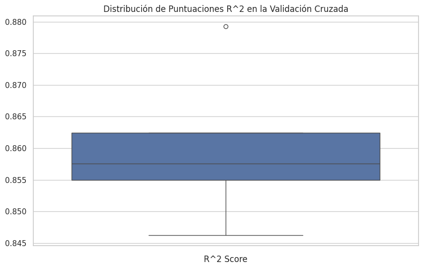

```python
plt.figure(figsize=(10, 6))
sns.boxplot(cv_results)
plt.title('Distribución de Puntuaciones R^2 en la Validación Cruzada')
plt.xlabel('R^2 Score')
plt.show()
```

### Conclusiones

A partir de los resultados obtenidos en la validación cruzada, podemos extraer las siguientes conclusiones:

1. **Distribución de las Puntuaciones R^2**:
   - Las puntuaciones R^2 obtenidas en cada pliegue de la validación cruzada son las siguientes: [0.86239941, 0.85756271, 0.87924151, 0.8549264, 0.84621344].
   - Observamos que las puntuaciones R^2 son bastante consistentes, con un rango que va desde aproximadamente 0.846 hasta 0.879.
2. **Puntuación Media R^2**:
   - La puntuación media R^2 obtenida a través de todos los pliegues es 0.8601. Esto indica que, en promedio, el modelo es capaz de explicar el 86.01% de la variabilidad en los datos de prueba, lo cual es un buen desempeño para un modelo de regresión.
3. **Interpretación del Boxplot**:
   - El boxplot muestra que la mayoría de las puntuaciones R^2 están concentradas entre 0.855 y 0.865, con un valor atípico (outlier) ligeramente superior a 0.875. Esto sugiere que, aunque hay cierta variabilidad en las puntuaciones, el modelo es relativamente robusto y ofrece un rendimiento consistente.
4. **Conclusión General**:
   - El modelo de regresión basado en Random Forest muestra un desempeño sólido, con una puntuación media R^2 que sugiere que el modelo es adecuado para predecir el valor de las propiedades en Bogotá con una buena precisión.

```python
from IPython.core.display import display, HTML

display(HTML('''
<div style="background-color: black; padding: 20px;">
<h1 style="text-align: center; font-size: 3em; color: #FF0000; font-weight: bold;">MODELO NO SUPERVISADO</h1>
'''))
```

MODELO NO SUPERVISADO

## Análisis No Supervisado con K-means

### 1. Preparación de los Datos

- Escalado de Datos
- Selección de Características

### 2. Determinación del Número Óptimo de Clústeres

- Método del Codo (Elbow Method)

### 3. Entrenamiento del Modelo K-means

### 4. Visualización de los Resultados

- Visualización de los Clústeres

### 1. Preparación de los Datos

Partimos de `df_cleaned`, nuestro dataset ya limpio y con las variables categóricas transformadas. En esta sección, realizaremos el escalado de los datos. El escalado es necesario porque el algoritmo K-means es sensible a las escalas de las variables. Asegurarnos de que todas las características tengan la misma escala garantiza que cada una contribuya de manera equitativa a la formación de los clústeres.

```python
import pandas as pd
from sklearn.preprocessing import StandardScaler

# Partimos de df_cleaned que  es el dataset limpio y transformado
# Seleccionar las características para el modelo K-means
features = ['Tipo', 'Habitaciones', 'Baños', 'Área', 'Barrio']

# Escalar los datos
scaler = StandardScaler()
X_scaled = scaler.fit_transform(df_cleaned[features])

# Mostrar una muestra de los datos escalados
print(X_scaled[:5])
print(df_cleaned.head())
```

```
[[-4.65680566e-01  2.47789694e-02 -2.52459865e-01 -3.16829600e-02
   1.33837528e+00]
 [ 1.61584973e+00  5.46090363e-01  6.92995308e-01  2.38180730e-02
  -1.11570905e+00]
 [-4.65680566e-01  2.47789694e-02  6.92995308e-01  9.38780441e-03
  -9.41797561e-01]
 [-4.65680566e-01  2.47789694e-02 -2.52459865e-01  1.49379077e-02
   1.14514029e+00]
 [-4.65680566e-01 -4.96532424e-01  6.92995308e-01  5.07639133e-04
  -1.40556153e+00]]
   Tipo  Habitaciones  Baños  Área  Barrio         Valor
0     0             3      2    70     148  3.600000e+08
1     2             4      3   170      21  6.700000e+08
2     0             3      3   144      30  1.120000e+09
3     0             3      2   154     138  8.900000e+08
4     0             2      3   128       6  9.700000e+08
```

### 2. Determinación del Número Óptimo de Clústeres

Para determinar el número óptimo de clústeres, utilizaremos el método del codo (Elbow Method). Este método implica calcular la suma de los errores cuadráticos (SSE) para diferentes números de clústeres y elegir el número de clústeres en el que la SSE comienza a disminuir a un ritmo constante.

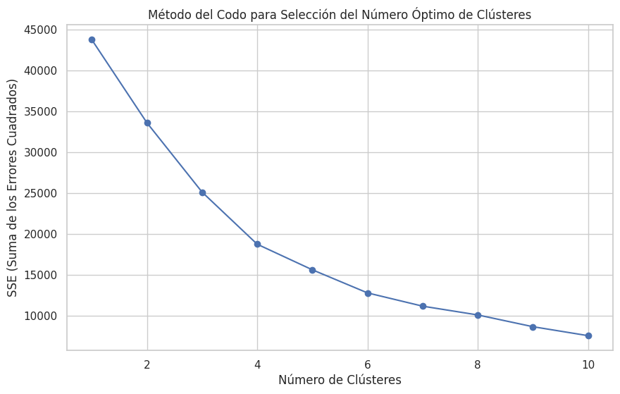

```python
from sklearn.cluster import KMeans
import matplotlib.pyplot as plt

# Método del Codo (Elbow Method) para determinar el número óptimo de clústeres
sse = []
k_range = range(1, 11)
for k in k_range:
    kmeans = KMeans(n_clusters=k, random_state=42)
    kmeans.fit(X_scaled)
    sse.append(kmeans.inertia_)

# Visualización del método del codo
plt.figure(figsize=(10, 6))
plt.plot(k_range, sse, 'bo-')
plt.xlabel('Número de Clústeres')
plt.ylabel('SSE (Suma de los Errores Cuadrados)')
plt.title('Método del Codo para Selección del Número Óptimo de Clústeres')
plt.show()
```

### 3. Entrenamiento del Modelo K-means

Una vez que hemos determinado el número óptimo de clústeres mediante el método del codo, podemos proceder a entrenar el modelo K-means con ese número de clústeres. En este ejemplo, supongamos que el número óptimo de clústeres es 5.

#### Entrenamiento del Modelo K-means

```python
# Aplicar el modelo K-means con el número óptimo de clústeres
kmeans = KMeans(n_clusters=5, random_state=42)  # Ajusta el número de clústeres según el codo
kmeans.fit(X_scaled)

# Añadir los clústeres al dataframe original
df_cleaned['Cluster'] = kmeans.labels_

# Mostrar una muestra del dataframe con los clústeres asignados
print(df_cleaned.head())
```

```
   Tipo  Habitaciones  Baños  Área  Barrio         Valor  Cluster
0     0             3      2    70     148  3.600000e+08        0
1     2             4      3   170      21  6.700000e+08        4
2     0             3      3   144      30  1.120000e+09        1
3     0             3      2   154     138  8.900000e+08        0
4     0             2      3   128       6  9.700000e+08        1
```

### 4. Visualización de los Resultados

Para entender mejor los clústeres formados por el modelo K-means, es útil visualizar los resultados. Usaremos PCA (Análisis de Componentes Principales) para reducir la dimensionalidad y representar los clústeres en un espacio bidimensional.

#### Visualización de los Clústeres

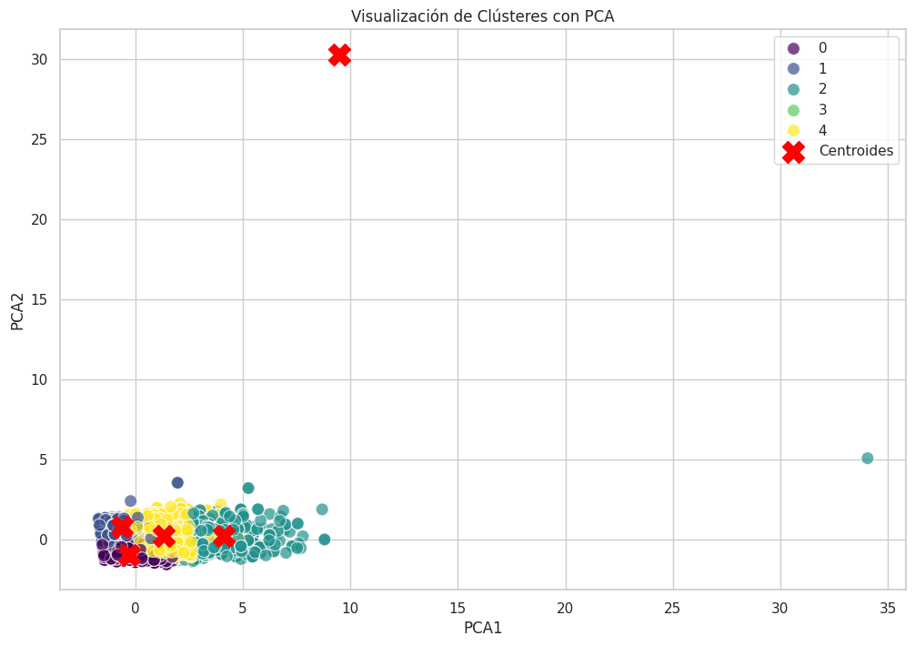

```python
import seaborn as sns
from sklearn.decomposition import PCA
import matplotlib.pyplot as plt

# PCA para reducción de dimensionalidad a 2 componentes
pca = PCA(n_components=2)
principal_components = pca.fit_transform(X_scaled)
df_pca = pd.DataFrame(data=principal_components, columns=['PCA1', 'PCA2'])
df_pca['Cluster'] = kmeans.labels_

# Visualización de los clústeres con centroides
plt.figure(figsize=(12, 8))
sns.scatterplot(x='PCA1', y='PCA2', hue='Cluster', data=df_pca, palette='viridis', s=100, alpha=0.7)
centroids = kmeans.cluster_centers_
centroids_pca = pca.transform(centroids)
plt.scatter(centroids_pca[:, 0], centroids_pca[:, 1], s=300, c='red', label='Centroides', marker='X')
plt.title('Visualización de Clústeres con PCA')
plt.xlabel('PCA1')
plt.ylabel('PCA2')
plt.legend()
plt.grid(True)
plt.show()
```

**Cómo partimos del dataset con las variables categoricas transformadas, hacemos un reverso de ello para interpretar mejor los datos.**

```python
# Revertir la codificación de las variables categóricas
df_cleaned['Tipo_Decoded'] = label_encoders['Tipo'].inverse_transform(df_cleaned['Tipo'])
df_cleaned['Barrio_Decoded'] = label_encoders['Barrio'].inverse_transform(df_cleaned['Barrio'])

# Mostrar una muestra del dataframe con las columnas decodificadas
print(df_cleaned[['Tipo', 'Tipo_Decoded', 'Barrio', 'Barrio_Decoded']].head())
```

```
   Tipo Tipo_Decoded  Barrio      Barrio_Decoded
0     0  Apartamento     148  Zona Noroccidental
1     2         Casa      21            Castilla
2     0  Apartamento      30     Chico Reservado
3     0  Apartamento     138             Usaquén
4     0  Apartamento       6         Bella Suiza
```

### Caracterización de los Clústeres

A continuación se presenta un análisis descriptivo de los clústeres formados mediante el modelo K-means. Este análisis incluye estadísticas como el promedio y la desviación estándar de las características principales.

#### Estadísticas Descriptivas por Clúster

```python
# Características descriptivas de cada clúster con categorías decodificadas
cluster_summary_decoded = df_cleaned.groupby('Cluster').agg({
    'Tipo_Decoded': lambda x: x.mode()[0],  # La moda puede ser más representativa
    'Habitaciones': ['mean', 'std'],
    'Baños': ['mean', 'std'],
    'Área': ['mean', 'std'],
    'Barrio_Decoded': lambda x: x.mode()[0],  # La moda puede ser más representativa
    'Valor': ['mean', 'std']
})

print(cluster_summary_decoded)
```

```
        Tipo_Decoded Habitaciones               Baños            \
            <lambda>         mean       std      mean       std
Cluster
0        Apartamento     2.530901  0.785515  2.201085  0.812091
1        Apartamento     2.549793  0.722789  1.929655  0.778268
2               Casa     8.286885  6.218593  5.038251  1.382339
3               Casa     4.000000       NaN  3.000000       NaN
4               Casa     3.579349  1.174647  2.562717  0.966525

                  Área                  Barrio_Decoded         Valor  \
                  mean         std            <lambda>          mean
Cluster
0            87.465179  102.234344             Usaquén  4.551875e+08
1            87.254621  401.855069                Bosa  3.810704e+08
2           348.013661  656.137955             Kennedy  7.671427e+08
3        166243.000000         NaN             Modelia  8.500000e+08
4           147.065142   88.513239  Zona Noroccidental  5.182187e+08


                  std
Cluster
0        2.527851e+08
1        2.506938e+08
2        2.841711e+08
3                 NaN
4        3.151649e+08
```

```python
# Número de valores en cada clúster
cluster_counts = df_cleaned.groupby('Cluster').size()

# Mostrar el conteo de valores por clúster
print(cluster_counts)
```

```
Cluster
0    3317
1    3625
2     366
3       1
4    1443
dtype: int64
```

```python
from IPython.core.display import display, HTML

display(HTML('''
<div style="background-color: black; padding: 20px;">
<h1 style="text-align: center; font-size: 3em; color: #FF0000; font-weight: bold;">DESARROLLO SEMANA 7(no supervisado): VALIDACIÓN CRUZADA</h1>
'''))
```

DESARROLLO SEMANA 7(no supervisado): VALIDACIÓN CRUZADA

### Estrategia de Validación Cruzada

En modelos no supervisados, la validación cruzada puede ser menos directa que en modelos supervisados. Sin embargo, una estrategia común es utilizar la estabilidad de los clusters en diferentes pliegues o la comparación de la inercia (SSE) en diferentes configuraciones de los datos.

Dado que K-Means es un algoritmo que se beneficia de tener un número de clusters predefinido, hemos determinado dicho número mediante el método del codo antes de aplicar el modelo. A diferencia de los modelos supervisados, donde se usan métricas específicas para validar la precisión, en modelos de clustering nos enfocamos en la consistencia de los clusters y la interpretación de los resultados obtenidos.

### Definición de Métrica de Evaluación

Para evaluar el rendimiento del modelo K-Means, hemos considerado la siguiente métrica:

1. **Inercia (Suma de los Errores Cuadrados, SSE)**:
   - La inercia mide la suma de las distancias al cuadrado entre cada punto de datos y el centroide del clúster más cercano. Un menor valor de inercia indica que los puntos están más cerca de sus centroides, lo que sugiere una mejor definición de los clusters.
   - Sin embargo, es importante tener en cuenta que la inercia disminuye a medida que se aumenta el número de clústeres, por lo que este valor debe ser interpretado en conjunto con el método del codo.

En conjunto con la inercia, la interpretación visual mediante la reducción de dimensionalidad (PCA) y la coherencia de los clústeres a nivel de las características originales también son fundamentales para evaluar el modelo.

### Realización de la Validación Cruzada

Dado que el modelo K-Means se utiliza en un contexto no supervisado, en lugar de realizar una validación cruzada tradicional, hemos validado la estabilidad del número de clusters a través del método del codo y hemos examinado la distribución y coherencia de los clusters utilizando técnicas de visualización como PCA.

La estabilidad del modelo se valida principalmente observando la consistencia de los resultados de clustering y la coherencia en la segmentación de datos a través de diferentes ejecuciones del algoritmo.

```python
from sklearn.cluster import KMeans
import numpy as np

# Inicializar el modelo K-Means con el número óptimo de clústeres
kmeans = KMeans(n_clusters=5, random_state=42)

# Realizar el ajuste y predicción
clusters = kmeans.fit_predict(X_scaled)

# Añadir las etiquetas de clúster al dataframe
df_cleaned['Cluster'] = clusters

# Verificar los resultados
print(df_cleaned[['Cluster']].head())
```

```
   Cluster
0        0
1        4
2        1
3        0
4        1
```

### Cálculo de la Puntuación Media

En modelos no supervisados, la puntuación media no se calcula de la misma manera que en modelos supervisados. En su lugar, la calidad del clustering se evalúa a través de la suma de los errores cuadrados (SSE) y la interpretación visual de la reducción de dimensionalidad.

La puntuación SSE nos indica la compacidad de los clusters formados, mientras que técnicas como PCA nos ayudan a visualizar la separación y coherencia de los clusters.

```python
# Calcular la puntuación de inercia (SSE)
sse = kmeans.inertia_

# Mostrar la puntuación SSE
print(f'Suma de los Errores Cuadrados (Inercia): {sse}')
```

```
Suma de los Errores Cuadrados (Inercia): 15587.93804375255
```

### Visualización de los Resultados

La visualización de los resultados de clustering es crucial para interpretar la segmentación de datos. Utilizamos PCA para reducir la dimensionalidad de los datos y visualizar los clústeres en un espacio de dos dimensiones. Esto nos permite observar la separación entre los clústeres y la proximidad de los puntos dentro de cada clúster.

Además, revertimos la codificación de las variables categóricas para facilitar la interpretación de los resultados, permitiéndonos caracterizar cada clúster en términos de las características originales.

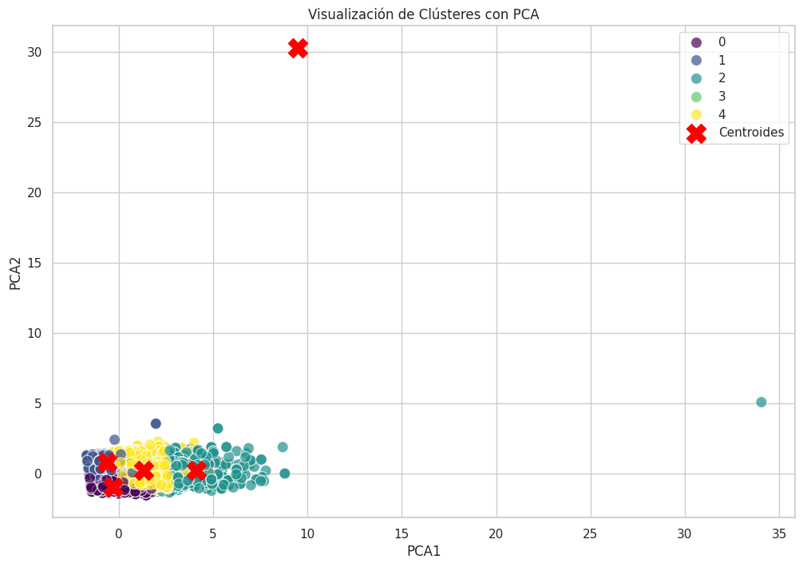

```python
import seaborn as sns
from sklearn.decomposition import PCA
import matplotlib.pyplot as plt

# PCA para reducción de dimensionalidad a 2 componentes
pca = PCA(n_components=2)
principal_components = pca.fit_transform(X_scaled)
df_pca = pd.DataFrame(data=principal_components, columns=['PCA1', 'PCA2'])
df_pca['Cluster'] = kmeans.labels_

# Visualización de los clústeres con centroides
plt.figure(figsize=(12, 8))
sns.scatterplot(x='PCA1', y='PCA2', hue='Cluster', data=df_pca, palette='viridis', s=100, alpha=0.7)
centroids = kmeans.cluster_centers_
centroids_pca = pca.transform(centroids)
plt.scatter(centroids_pca[:, 0], centroids_pca[:, 1], s=300, c='red', label='Centroides', marker='X')
plt.title('Visualización de Clústeres con PCA')
plt.xlabel('PCA1')
plt.ylabel('PCA2')
plt.legend()
plt.grid(True)
plt.show()
```

### Conclusiones

A partir de los resultados obtenidos en el análisis de clustering utilizando el algoritmo K-Means, podemos extraer las siguientes conclusiones:

```python
from IPython.core.display import display, HTML

display(HTML('''
<div style="background-color: black; padding: 20px;">
<h1 style="text-align: center; font-size: 3em; color: #FF0000; font-weight: bold;">CONCLUSIONES NO SUPERVISADO</h1>
'''))
```

CONCLUSIONES NO SUPERVISADO

## Conclusiones del Análisis

### Resumen del Clúster

[output not shown]

### Conclusiones

#### Diversidad de Clústeres:

```python
from IPython.core.display import display, HTML

display(HTML('''
<div style="background-color: black; padding: 20px;">
<h1 style="text-align: center; font-size: 3em; color: #FF0000; font-weight: bold;">REFERENCIAS</h1>
'''))
```

REFERENCIAS

## Referencias:

- Bi, O. et al. (2019). What is Machine Learning? A Primer for the Epidemiologist. American Journal of Epidemiology, 188(12), 2222–2239.
- Carsten, B. (2020). Perspectives on Artificial Intelligence. En Artificial Intelligence for a Better Future: An Ecosystem Perspective on the Ethics of AI and Emerging Digital Technologies (pp. 7-35). Springer.
- Cabanelas, J. (2019). Inteligencia artificial ¿Dr. Jekyll o Mr. Hyde? Mercados y Negocios, (40), 5-22.
- Palanisamy, P. (2018). Introduction to intelligent agents and learning environments. En Hands-On Intelligent Agents with OpenAI Gym: Your Guide to Developing AI Agents Using Deep Reinforcement Learning (pp. 7-20). Packt Publishing, Limited.
- [Real Estate Bogota Dataset](https://www.kaggle.com/datasets/pablobravo73/real-estate-bogota) (Análisis del mercado inmobiliario en Bogotá)